# Assessment

#### (7)

```r
sample_Xs <- function(a, b, n) {
  prob_0 <- (choose(a, 1) * choose(b, 1)) / choose(a + b, 2)
  prob_2 <- (choose(a, 2) * choose(b, 0)) / choose(a + b, 2)

  prob_neg2 = (choose(a, 0) * choose(b, 2)) / choose(a + b, 2)
  # prob_neg2: Probability of choosing 0 red balls and 2 blue balls

  samples <- sample(c(0, 2, -2), size = n, prob = c(prob_0, prob_2, prob_neg2), replace = T)
  return(samples)
}

table(sample_Xs(3, 5, 100))
```

```
##
## -2  0  2
## 30 54 16
```

#### (8)

```r
a = 3
b = 5
n = 100000
Samples <- sample_Xs(a, b, n)

Expectation <- compute_expectation_X(a, b)
Variance <- compute_variance_X(a, b)

sampleMean <- mean(Samples)
sampleVariance <- var(Samples)

print(Expectation)
```

```
## [1] -0.5
```

```r
print(Variance)
```

```
## [1] 1.607143
```

```r
print(sampleMean)
```

```
## [1] -0.50138
```

```r
print(sampleVariance)
```

```
## [1] 1.597474
```

The expectation calculated using the function `compute_expectation_X` is -0.5 whereas the sample mean is -0.50138. As it is seen these two values are almost equal. That is, the sample mean and the expectation of the sample are similar.

#### (9)

```r
mu_0 <- Expectation
n = 900
sigma_0 <- sqrt(Variance / n)
a = 3
b = 5

num_trials <- 20000

simStudyDf <- data.frame(trials = rep(n, num_trials)) %>%
  mutate(samples = map(trials, ~sample_Xs(a, b, .x))) %>%
  mutate(sampleMean = map_dbl(samples, mean))
```

#### (9)

```r
mu_minus_sigma_calc <- function(mu, sig) {
  return(mu - sig)
}

densityPlotDf <- data.frame(sigma = seq(-3 * sigma_0, 3 * sigma_0, 0.1 * sigma_0)) %>%
  mutate(newSeq = map_dbl(sigma, ~mu_minus_sigma_calc(mu_0, .x))) %>%
  mutate(GuassianDistr = map_dbl(.x = newSeq, ~dnorm(.x, mean = mu_0, sd = sigma_0)))
```

#### (10)

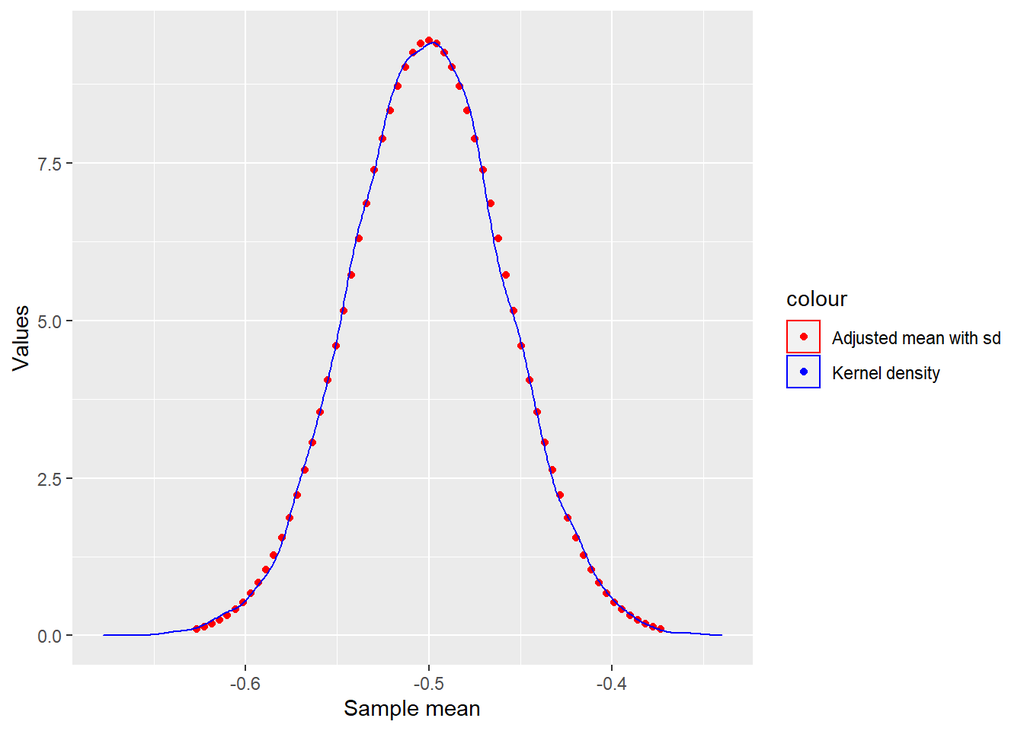

```r
color <- c("Adjusted mean with sd" = "red", "Kernel density" = "blue")

ggplot(densityPlotDf) +
  geom_point(aes(x = newSeq, y = GuassianDistr, color = "Adjusted mean with sd")) +
  geom_density(data = simStudyDf, aes(x = sampleMean, color = "Kernel density")) +
  ylab('Values') +
  xlab("Sample mean") +
  scale_color_manual(values = color)
```

#### (11)

The Kernel density of $\bar{X}$ follows the same curve as the scatter plot plotted with function $f_{\mu, \sigma}$ which is a Gaussian distribution.

In our simulation study we had a small standard deviation i.e., a very narrow peak in our plot. And that is why, it coincides with the normal distribution plot. Although, it is slightly smoother and more flexible than the normal distribution, since it is a non-parametric method that does not rely on any assumptions about the underlying distribution.